# DM_Project

##### **(e)** Visualisation of new columns

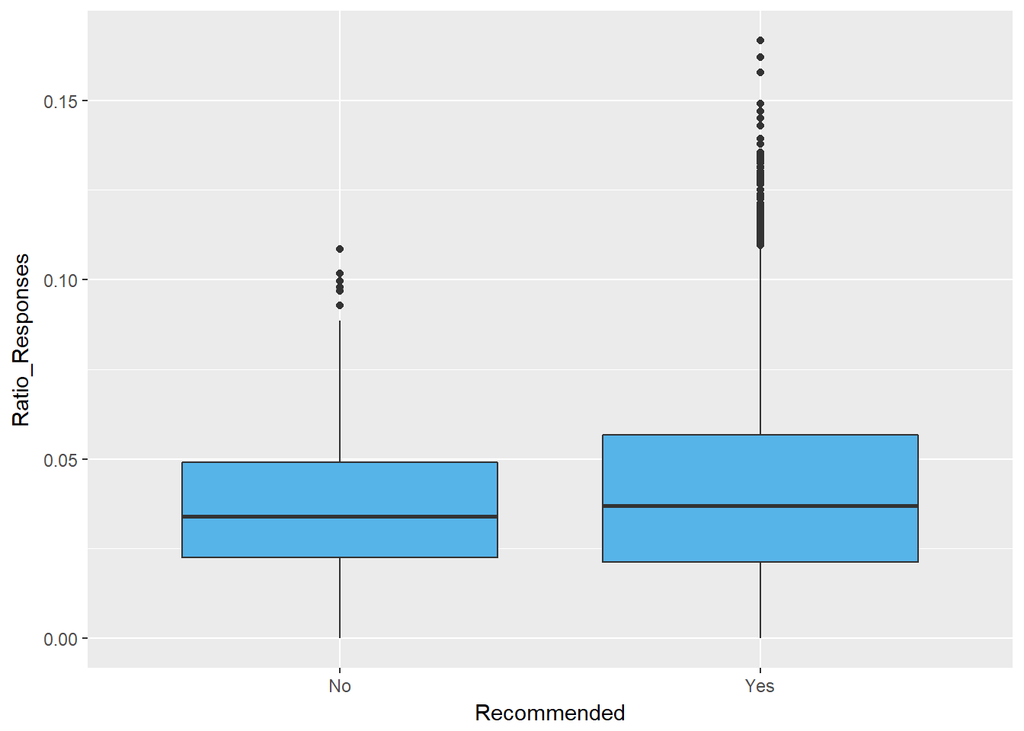

```r
suggestions_vis = transform(suggestions_new,
                   Recommended = mapvalues(Recommended, c(0,1),
                                      c("Yes", "No")))
qplot(data = suggestions_vis, x = Recommended, y = Ratio_Responses , fill = I(cbPalette[3]), geom = "boxplot")
```

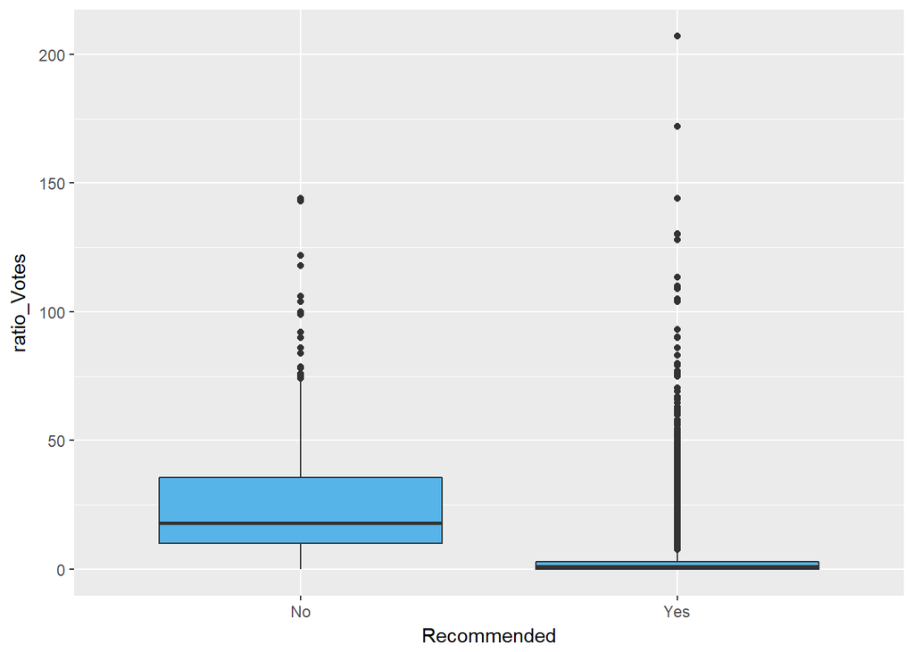

```r
qplot(data = suggestions_vis, x = Recommended, y = ratio_Votes , fill = I(cbPalette[3]), geom = "boxplot")
```

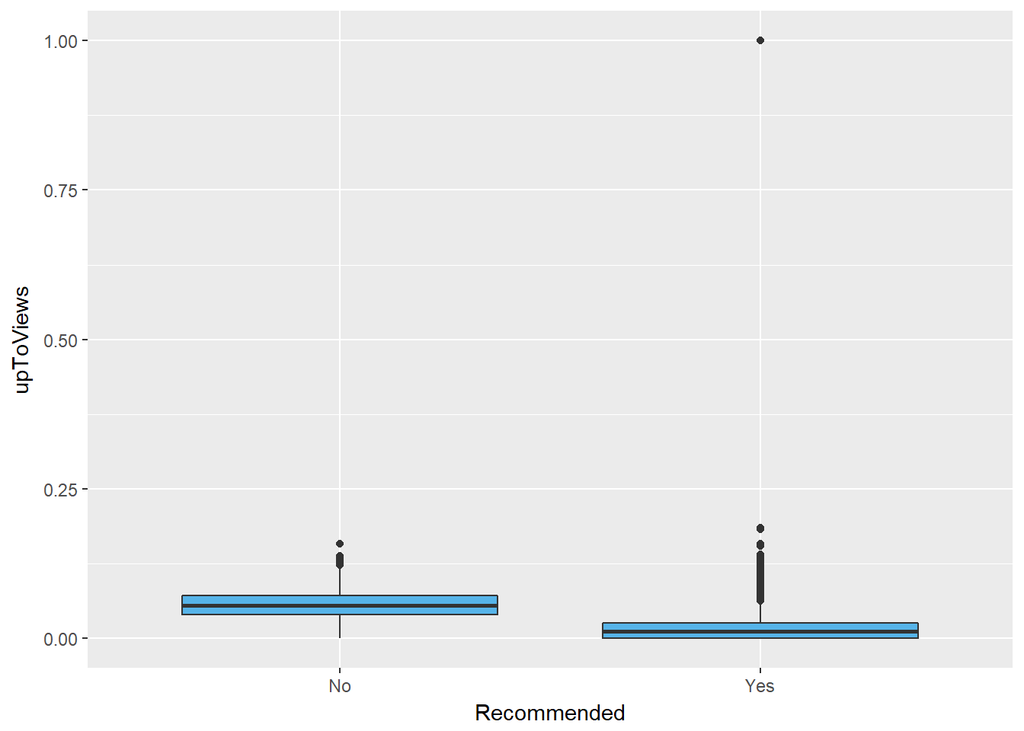

```r
qplot(data = suggestions_vis, x = Recommended, y = upToViews , fill = I(cbPalette[3]), geom = "boxplot")+coord_cartesian(ylim = c(0, 1))
```

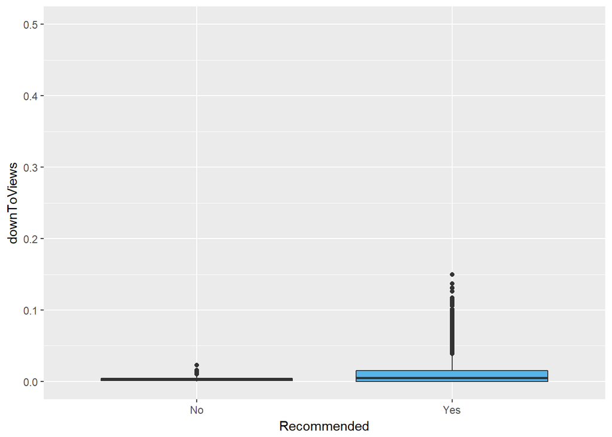

```r
qplot(data = suggestions_vis, x = Recommended, y = downToViews , fill = I(cbPalette[3]), geom = "boxplot")+coord_cartesian(ylim = c(0, 0.5))
```

### Feature Selection

##### **(f)** Baseline Logistic Regression for significant features

> To identify the features most predictive of a good/bad suggestion using the P-values

```r
suggestions.glm = glm(Recommended~ .,family=binomial, data = suggestions_new)
summary(suggestions.glm)
```

```
##
## Call:
## glm(formula = Recommended ~ ., family = binomial, data = suggestions_new)
##
## Deviance Residuals:
##     Min       1Q   Median       3Q      Max
## -4.9657  -0.1703  -0.1349  -0.1115   3.3139
##
## Coefficients:
##                                                                 Estimate
## (Intercept)                                                -2.0926048834
## Responses                                                   0.0226079225
## Views                                                       0.0001683552
## Votes_Up                                                    0.0014924736
## Votes_Down                                                 -0.0589103988
## Author_Id                                                  -0.0000016852
## Author_Join..in.terms.of.how.many.days.since.they.joined.  -0.0014248774
## Author_TotalPosts                                           0.0000324396
## Author_PostsPerDay                                          0.3418224151
## ratio_Votes                                                 0.0651674633
## Ratio_Responses                                           -11.2263778406
## upToViews                                                  -0.0026323211
## downToViews                                                 0.1086424986
##                                                               Std. Error
## (Intercept)                                                 1.8150963015
## Responses                                                   0.0026752410
## Views                                                       0.0000305838
## Votes_Up                                                    0.0013531936
## Votes_Down                                                  0.0086932254
## Author_Id                                                   0.0000009615
## Author_Join..in.terms.of.how.many.days.since.they.joined.   0.0011723606
## Author_TotalPosts                                           0.0000877448
## Author_PostsPerDay                                          0.0982714193
## ratio_Votes                                                 0.0038967794
## Ratio_Responses                                             2.7556074474
## upToViews                                                   0.0037481834
## downToViews                                                 0.0391464836
##                                                           z value Pr(>|z|)
## (Intercept)                                                -1.153 0.248956
## Responses                                                   8.451  < 2e-16
```

[output cut: 20 more lines]

```
## Author_PostsPerDay                                        ***
## ratio_Votes                                               ***
## Ratio_Responses                                           ***
## upToViews
## downToViews                                               **
## ---
## Signif. codes:  0 '***' 0.001 '**' 0.01 '*' 0.05 '.' 0.1 ' ' 1
##
## (Dispersion parameter for binomial family taken to be 1)
##
##     Null deviance: 4898.0  on 16422  degrees of freedom
## Residual deviance: 3019.8  on 16410  degrees of freedom
## AIC: 3045.8
##
## Number of Fisher Scoring iterations: 7
```

> Logistic regression after downsampling

```r
suggestions_0 = suggestions_new[suggestions_new$Recommended==0,]
suggestions_1 = suggestions_new[suggestions_new$Recommended==1,]
suggestions_0_sample = suggestions_0[sample(1:nrow(suggestions_1)),]
suggestions_new1 = rbind(suggestions_1,suggestions_0_sample)

suggestions.glm1 = glm(Recommended~ .,family=binomial, data = suggestions_new1)
summary(suggestions.glm1)
```

```
##
## Call:
## glm(formula = Recommended ~ ., family = binomial, data = suggestions_new1)
##
## Deviance Residuals:
##     Min       1Q   Median       3Q      Max
## -4.9084  -0.5608  -0.1178   0.5200   2.8953
##
## Coefficients:
##                                                                Estimate
## (Intercept)                                               -10.098754979
## Responses                                                   0.018417178
## Views                                                       0.000099607
## Votes_Up                                                   -0.002887411
## Votes_Down                                                 -0.037483514
## Author_Id                                                   0.000006625
## Author_Join..in.terms.of.how.many.days.since.they.joined.   0.005134013
## Author_TotalPosts                                          -0.000895800
## Author_PostsPerDay                                          1.566458660
## ratio_Votes                                                 0.077506065
## Ratio_Responses                                           -15.977852014
## upToViews                                                  -0.003493010
## downToViews                                                 0.014921650
##                                                              Std. Error
## (Intercept)                                                 3.860340284
## Responses                                                   0.004503448
## Views                                                       0.000039388
## Votes_Up                                                    0.001783124
## Votes_Down                                                  0.010280057
## Author_Id                                                   0.000002128
## Author_Join..in.terms.of.how.many.days.since.they.joined.   0.002485365
## Author_TotalPosts                                           0.000386339
## Author_PostsPerDay                                          0.506999876
## ratio_Votes                                                 0.008479464
## Ratio_Responses                                             4.697638158
## upToViews                                                   0.004294929
## downToViews                                                 0.044019698
##                                                           z value
## (Intercept)                                                -2.616
## Responses                                                   4.090
```

[output cut: 20 more lines]

```
## Author_PostsPerDay                                         0.002004 **
## ratio_Votes                                                 < 2e-16 ***
## Ratio_Responses                                            0.000671 ***
## upToViews                                                  0.416054
## downToViews                                                0.734627
## ---
## Signif. codes:  0 '***' 0.001 '**' 0.01 '*' 0.05 '.' 0.1 ' ' 1
##
## (Dispersion parameter for binomial family taken to be 1)
##
##     Null deviance: 1558.19  on 1123  degrees of freedom
## Residual deviance:  872.51  on 1111  degrees of freedom
## AIC: 898.51
##
## Number of Fisher Scoring iterations: 6
```

From The above observations we can say that certaiin features are clearly predictive in the classification task. This includes -Responses, Views, Votes_Down, Author_Id, Author_Join, Author_PostsPerDay and ratio_Votes. Before proceeding with feature selection, we would like to look at some feature selection methods to check which parameters among these is the smallest set of predictive features since unregularized regression does not capture interaction among terms.

##### **(g)** Correlation Analysis

> Pairplots

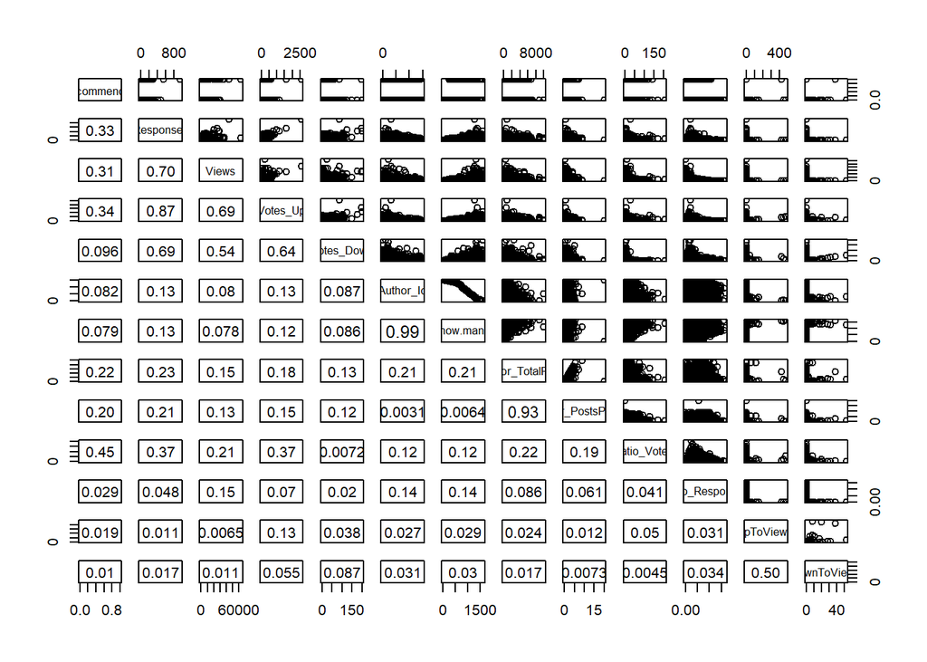

We can clearly see that certain features are correlated. Including both among such correlated pairs would mean redundancy of information, more time to train the model [In case of extremely large datasets] and can potentially add noise to the model.

> Heat Map for correlation

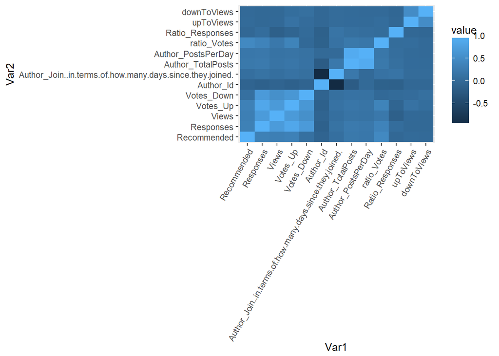

```r
qplot(x=Var1, y=Var2, data=melt(cor(suggestions_new)), fill=value, geom="tile")+ theme(axis.text.x = element_text(angle=60, hjust=1))
```

We can notice high correlation between the following pairs-

Author_id and days since joined - This can be inferred as ids being assigned as newer employees join

Author_totalposts and Author_postsperday

Since these variables are highly correlated, we can remove one among each pair.

> Logistic regression after feature removal based on above analysis

```r
suggestions_new2 = subset(suggestions_new1,select = -c(Author_Id,Author_PostsPerDay))
suggestions.glm2 = glm(Recommended~ .,family=binomial, data = suggestions_new2)
summary(suggestions.glm2)
```

```
##
## Call:
## glm(formula = Recommended ~ ., family = binomial, data = suggestions_new2)
##
## Deviance Residuals:
##     Min       1Q   Median       3Q      Max
## -5.0608  -0.5875  -0.1026   0.5529   2.8090
##
## Coefficients:
##                                                               Estimate
## (Intercept)                                                 3.40458934
## Responses                                                   0.01731611
## Views                                                       0.00010401
## Votes_Up                                                   -0.00276262
## Votes_Down                                                 -0.03721652
## Author_Join..in.terms.of.how.many.days.since.they.joined.  -0.00374353
## Author_TotalPosts                                           0.00031754
## ratio_Votes                                                 0.08301211
## Ratio_Responses                                           -16.95218252
## upToViews                                                  -0.00348884
## downToViews                                                 0.00698349
##                                                             Std. Error
## (Intercept)                                                 0.56990535
## Responses                                                   0.00448817
## Views                                                       0.00004184
## Votes_Up                                                    0.00176153
## Votes_Down                                                  0.01003218
## Author_Join..in.terms.of.how.many.days.since.they.joined.   0.00042731
## Author_TotalPosts                                           0.00005223
## ratio_Votes                                                 0.00852011
## Ratio_Responses                                             4.67643439
## upToViews                                                   0.00456155
## downToViews                                                 0.04767638
##                                                           z value Pr(>|z|)
## (Intercept)                                                 5.974 2.32e-09
## Responses                                                   3.858 0.000114
## Views                                                       2.486 0.012928
## Votes_Up                                                   -1.568 0.116810
## Votes_Down                                                 -3.710 0.000207
## Author_Join..in.terms.of.how.many.days.since.they.joined.  -8.761  < 2e-16
```

[output cut: 12 more lines]

```
## Author_TotalPosts                                         ***
## ratio_Votes                                               ***
## Ratio_Responses                                           ***
## upToViews
## downToViews
## ---
## Signif. codes:  0 '***' 0.001 '**' 0.01 '*' 0.05 '.' 0.1 ' ' 1
##
## (Dispersion parameter for binomial family taken to be 1)
##
##     Null deviance: 1558.19  on 1123  degrees of freedom
## Residual deviance:  892.81  on 1113  degrees of freedom
## AIC: 914.81
##
## Number of Fisher Scoring iterations: 6
```

##### **(h)** Feature Selection through best subest selection and Regularisation

**Best Subest selection tries to find the best choice of predictors to use. Below are Forward and Backwars stepwise selection methods that pick the best model by using AIC and BIC as penalising factors**

> Forward Stepwise with AIC

```r
#Forward-AIC takes around 15 minutes to run
suggestions_new.best.logistics <- within(suggestions_new, {
    y <- Recommended         # bwt into y
    Recommended <- NULL
})

suggestions_new.stepwise <-
    suggestions_new.best.logistics[, c("Responses","Views","Votes_Up","Votes_Down","Author_Id","Author_Join..in.terms.of.how.many.days.since.they.joined.","Author_TotalPosts","Author_PostsPerDay","ratio_Votes","Ratio_Responses","upToViews","downToViews","y")]

fwd.best.logisticAIC <-
    bestglm(Xy = suggestions_new.stepwise,
            family = binomial,          # binomial family for logistic
            IC = "AIC",                 # Information criteria for
            method = "forward")
```

```
## Morgan-Tatar search since family is non-gaussian.
```

```r
fwd.best.logisticAIC$BestModels
```

```
##   Responses Views Votes_Up Votes_Down Author_Id
## 1      TRUE  TRUE    FALSE       TRUE      TRUE
## 2      TRUE  TRUE    FALSE       TRUE      TRUE
## 3      TRUE  TRUE     TRUE       TRUE      TRUE
## 4      TRUE  TRUE     TRUE       TRUE      TRUE
## 5      TRUE  TRUE    FALSE       TRUE     FALSE
##   Author_Join..in.terms.of.how.many.days.since.they.joined.
## 1                                                     FALSE
## 2                                                      TRUE
## 3                                                     FALSE
## 4                                                      TRUE
## 5                                                      TRUE
##   Author_TotalPosts Author_PostsPerDay ratio_Votes Ratio_Responses
## 1             FALSE               TRUE        TRUE            TRUE
## 2             FALSE               TRUE        TRUE            TRUE
## 3             FALSE               TRUE        TRUE            TRUE
## 4             FALSE               TRUE        TRUE            TRUE
## 5             FALSE               TRUE        TRUE            TRUE
##   upToViews downToViews Criterion
## 1     FALSE        TRUE  3038.814
## 2     FALSE        TRUE  3039.307
## 3     FALSE        TRUE  3039.925
## 4     FALSE        TRUE  3040.441
## 5     FALSE        TRUE  3040.570
```

```r
formula(fwd.best.logisticAIC$BestModel)
```

```
## y ~ Responses + Views + Votes_Down + Author_Id + Author_PostsPerDay +
##     ratio_Votes + Ratio_Responses + downToViews
## <environment: 0x00000000157da828>
```

```r
plot(seq_len(nrow(fwd.best.logisticAIC$Subsets)) - 1, fwd.best.logisticAIC$Subsets[,"AIC"], type="b", xlab = "Number of Predictors", ylab = "AIC")
```

[output not shown]

** Feature Selection (Forward Selection - AIC) gives the minimum AIC with 8 predictors model: Responses + Views + Votes_Down + Author_Id + Author_PostsPerDay + ratio_Votes + Ratio_Responses + downToViews**

> Backward stepwise - AIC

```r
#Backward-AIC takes around 15 minutes to run
bckwd.best.logisticAIC <-
    bestglm(Xy = suggestions_new.stepwise,
            family = binomial,          # binomial family for logistic
            IC = "AIC",                 # Information criteria for
            method = "backward")
```

```
## Morgan-Tatar search since family is non-gaussian.
```

```r
bckwd.best.logisticAIC$BestModels
```

```
##   Responses Views Votes_Up Votes_Down Author_Id
## 1      TRUE  TRUE    FALSE       TRUE      TRUE
## 2      TRUE  TRUE    FALSE       TRUE      TRUE
## 3      TRUE  TRUE     TRUE       TRUE      TRUE
## 4      TRUE  TRUE     TRUE       TRUE      TRUE
## 5      TRUE  TRUE    FALSE       TRUE     FALSE
##   Author_Join..in.terms.of.how.many.days.since.they.joined.
## 1                                                     FALSE
## 2                                                      TRUE
## 3                                                     FALSE
## 4                                                      TRUE
## 5                                                      TRUE
##   Author_TotalPosts Author_PostsPerDay ratio_Votes Ratio_Responses
## 1             FALSE               TRUE        TRUE            TRUE
## 2             FALSE               TRUE        TRUE            TRUE
## 3             FALSE               TRUE        TRUE            TRUE
## 4             FALSE               TRUE        TRUE            TRUE
## 5             FALSE               TRUE        TRUE            TRUE
##   upToViews downToViews Criterion
## 1     FALSE        TRUE  3038.814
## 2     FALSE        TRUE  3039.307
## 3     FALSE        TRUE  3039.925
## 4     FALSE        TRUE  3040.441
## 5     FALSE        TRUE  3040.570
```

```r
formula(bckwd.best.logisticAIC$BestModel)
```

```
## y ~ Responses + Views + Votes_Down + Author_Id + Author_PostsPerDay +
##     ratio_Votes + Ratio_Responses + downToViews
## <environment: 0x000000006222e018>
```

```r
plot(seq_len(nrow(bckwd.best.logisticAIC$Subsets)) - 1, bckwd.best.logisticAIC$Subsets[,"AIC"], type="b", xlab = "Number of Predictors", ylab = "AIC")
```

[output not shown]

** Feature Selection (Backward Selection - AIC) also gives the minimum AIC with same 8 predictors model: Responses + Views + Votes_Down + Author_Id + Author_PostsPerDay + ratio_Votes + Ratio_Responses + downToViews**

> Exhaustive - AIC

```r
#Exhaustive-AIC takes around 15 minutes to run
ex.best.logisticAIC <-
    bestglm(Xy = suggestions_new.stepwise,
            family = binomial,          # binomial family for logistic
            IC = "AIC",                 # Information criteria for
            method = "exhaustive")
```

```
## Morgan-Tatar search since family is non-gaussian.
```

```r
ex.best.logisticAIC$BestModels
```

```
##   Responses Views Votes_Up Votes_Down Author_Id
## 1      TRUE  TRUE    FALSE       TRUE      TRUE
## 2      TRUE  TRUE    FALSE       TRUE      TRUE
## 3      TRUE  TRUE     TRUE       TRUE      TRUE
## 4      TRUE  TRUE     TRUE       TRUE      TRUE
## 5      TRUE  TRUE    FALSE       TRUE     FALSE
##   Author_Join..in.terms.of.how.many.days.since.they.joined.
## 1                                                     FALSE
## 2                                                      TRUE
## 3                                                     FALSE
## 4                                                      TRUE
## 5                                                      TRUE
##   Author_TotalPosts Author_PostsPerDay ratio_Votes Ratio_Responses
## 1             FALSE               TRUE        TRUE            TRUE
## 2             FALSE               TRUE        TRUE            TRUE
## 3             FALSE               TRUE        TRUE            TRUE
## 4             FALSE               TRUE        TRUE            TRUE
## 5             FALSE               TRUE        TRUE            TRUE
##   upToViews downToViews Criterion
## 1     FALSE        TRUE  3038.814
## 2     FALSE        TRUE  3039.307
## 3     FALSE        TRUE  3039.925
## 4     FALSE        TRUE  3040.441
## 5     FALSE        TRUE  3040.570
```

```r
formula(ex.best.logisticAIC$BestModel)
```

```
## y ~ Responses + Views + Votes_Down + Author_Id + Author_PostsPerDay +
##     ratio_Votes + Ratio_Responses + downToViews
## <environment: 0x00000000610054d0>
```

```r
plot(seq_len(nrow(ex.best.logisticAIC$Subsets)) - 1, ex.best.logisticAIC$Subsets[,"AIC"], type="b", xlab = "Number of Predictors", ylab = "AIC")
```

[output not shown]

** Feature Selection (Exhaustive AIC): also gives the minimum AIC with the same 8 predictors model: Responses + Views + Votes_Down + Author_Id + Author_PostsPerDay + ratio_Votes + Ratio_Responses + downToViews**

> Lasso

**An Alternative to Best subset is regularized regression. Herecertain features’ regression coefficients are shrunk to zero.**

Best Lambda

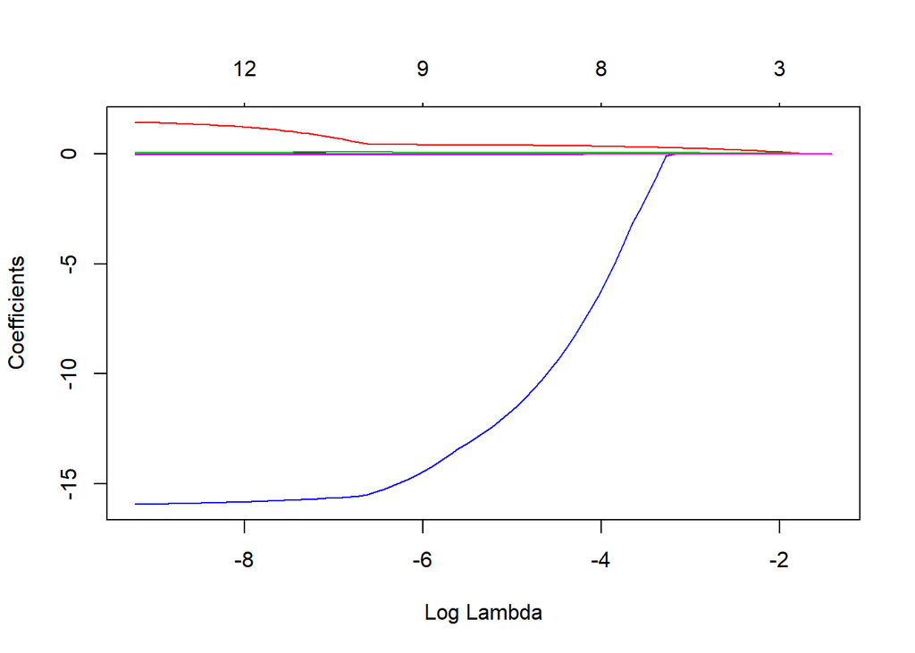

```r
x<-as.matrix(suggestions_new1[,-1])
# Note alpha=1 for lasso only and can blend with ridge penalty down to
# alpha=0 ridge only.
glmmod <- glmnet(x, y=suggestions_new1$Recommended, alpha=1, family="binomial")

# Plot variable coefficients vs. shrinkage parameter lambda.
plot(glmmod, xvar="lambda")
```

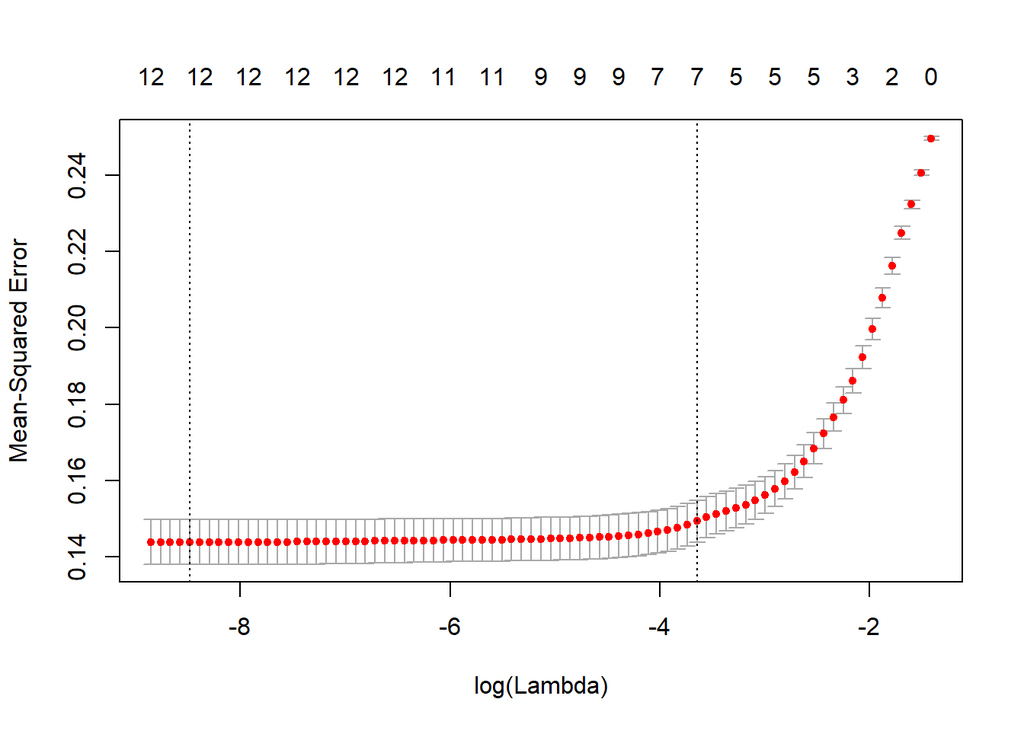

```r
cv.glmmod <- cv.glmnet(x, y=suggestions_new1$Recommended, alpha=1)
plot(cv.glmmod)
```

```r
best.lambda <- cv.glmmod$lambda.min
se.lambda=cv.glmmod$lambda.1se

lambda.best = predict(glmmod,type = "coefficients", s = best.lambda)
lambda.best
```

```
## 13 x 1 sparse Matrix of class "dgCMatrix"
##                                                                          1
## (Intercept)                                                -8.627984966212
## Responses                                                   0.017848774091
## Views                                                       0.000098034631
## Votes_Up                                                   -0.002707962787
## Votes_Down                                                 -0.037004841818
## Author_Id                                                   0.000005915325
## Author_Join..in.terms.of.how.many.days.since.they.joined.   0.004167836284
## Author_TotalPosts                                          -0.000722506674
## Author_PostsPerDay                                          1.341927605963
## ratio_Votes                                                 0.077695564670
## Ratio_Responses                                           -15.880527674195
## upToViews                                                  -0.003527900416
## downToViews                                                 0.011969075334
```

```r
#mse with min lambda
print(paste0("mse with min lambda : ",cv.glmmod$cvm[cv.glmmod$lambda == best.lambda]))
```

```
## [1] "mse with min lambda : 0.1438809915303"
```

**Feature Selection after Lasso (Best Lambda) : Responses, Views, Votes_Down,Votes_Up,Author_Id, Author_Join, Author_TotalPosts, Author_PostsPerDay, Ratio_Votes, Ratio_Responses, upToViews, downtoViews**

1SE Lambda

```r
lambda.1se = predict(glmmod,type = "coefficients", s = se.lambda)
lambda.1se
```

```
## 13 x 1 sparse Matrix of class "dgCMatrix"
##                                                                       1
## (Intercept)                                               -1.990573e+00
## Responses                                                  1.769815e-03
## Views                                                      4.963594e-05
## Votes_Up                                                   .
## Votes_Down                                                -4.926759e-04
## Author_Id                                                  1.977183e-06
## Author_Join..in.terms.of.how.many.days.since.they.joined.  .
## Author_TotalPosts                                          .
## Author_PostsPerDay                                         3.233635e-01
## ratio_Votes                                                6.516424e-02
## Ratio_Responses                                           -3.131758e+00
## upToViews                                                 -3.007071e-17
## downToViews                                                .
```

```r
#mse with 1se lambda
print(paste0("mse with min lambda :",cv.glmmod$cvm[cv.glmmod$lambda == se.lambda]))
```

```
## [1] "mse with min lambda :0.149378041567518"
```

**Feature Selection after Lasso (Lambda 1SE) : Responses, Views, Votes_Down, Author_Id, Author_PostsPerDay, Ratio_Votes, Ratio_Responses, upToViews**

##### **(i)** Feature Selection through Decision Tree and Random Forests

To get validate the features selected from above methods, Decision Trees and Random Forests were run on the data.

> Decision Tree

```r
tree.sugg <- tree::tree(Recommended ~ . -Recommended, suggestions_new1)
summary(tree.sugg)
```

```
##
## Regression tree:
## tree::tree(formula = Recommended ~ . - Recommended, data = suggestions_new1)
## Variables actually used in tree construction:
## [1] "ratio_Votes" "Views"       "Votes_Down"  "Votes_Up"    "Responses"
## Number of terminal nodes:  7
## Residual mean deviance:  0.06386 = 71.33 / 1117
## Distribution of residuals:
##     Min.  1st Qu.   Median     Mean  3rd Qu.     Max.
## -0.91410 -0.01848  0.00000  0.00000  0.08587  0.98150
```

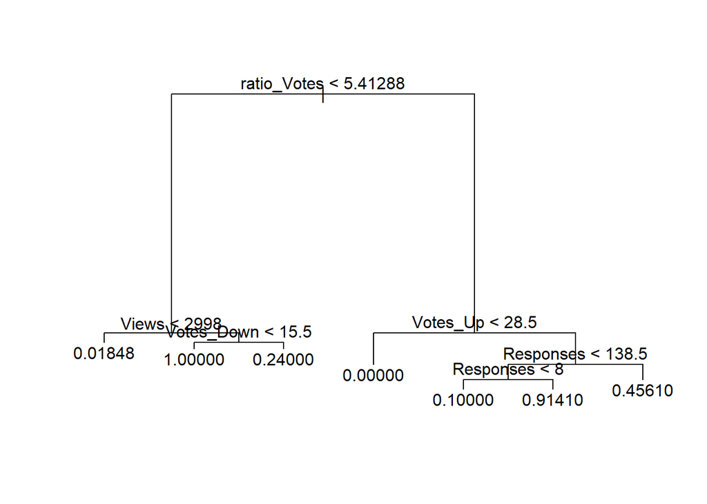

```r
plot(tree.sugg)
text(tree.sugg,pretty=0)
```

```r
summary(tree.sugg)$used ## variables used
```

```
## [1] ratio_Votes Views       Votes_Down  Votes_Up    Responses
## 13 Levels: <leaf> Responses Views Votes_Up Votes_Down ... downToViews
```

```r
names(suggestions_new)[which(!(names(suggestions_new) %in%summary(tree.sugg)$used))] ## variables not used
```

```
## [1] "Recommended"
## [2] "Author_Id"
## [3] "Author_Join..in.terms.of.how.many.days.since.they.joined."
## [4] "Author_TotalPosts"
## [5] "Author_PostsPerDay"
## [6] "Ratio_Responses"
## [7] "upToViews"
## [8] "downToViews"
```

> Random Forests

```r
set.seed(1)
suggestions.rf <- randomForest(Recommended ~ .,data=suggestions_new1,mtry=4,importance = TRUE)
#names(suggestions_new1)
show(suggestions.rf)
```

```
##
## Call:
##  randomForest(formula = Recommended ~ ., data = suggestions_new1,      mtry = 4, importance = TRUE)
##                Type of random forest: regression
##                      Number of trees: 500
## No. of variables tried at each split: 4
##
##           Mean of squared residuals: 0.06067506
##                     % Var explained: 75.73
```

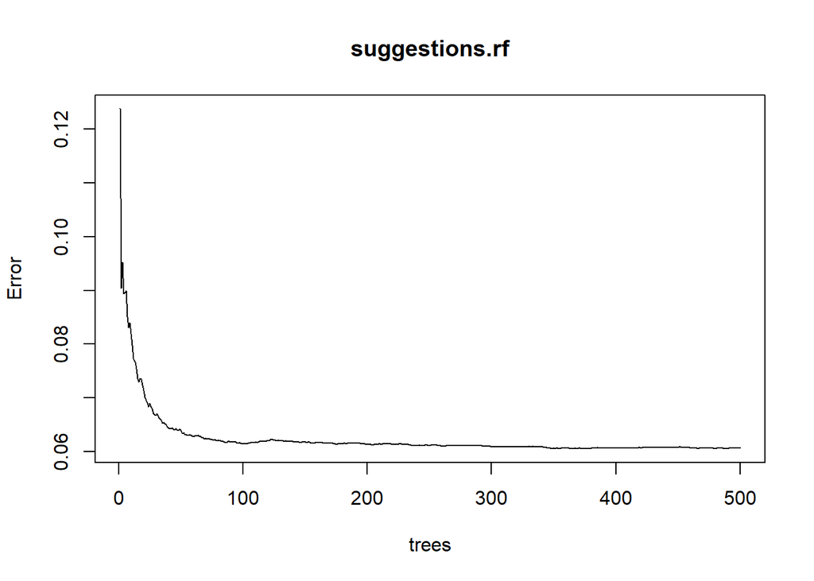

```r
plot(suggestions.rf)
```

The above plot shows the out-of-bag MSE curve as a function of the number of trees

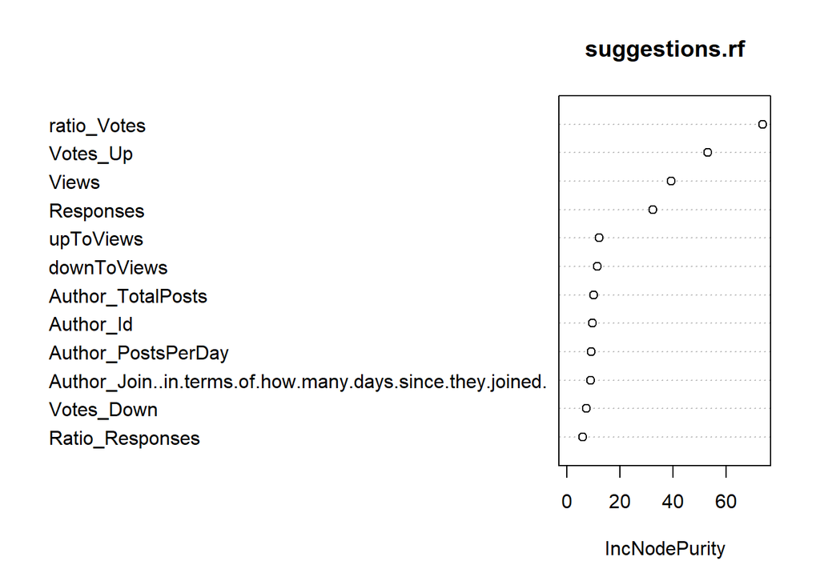

```r
varImpPlot(suggestions.rf,type=2)
```

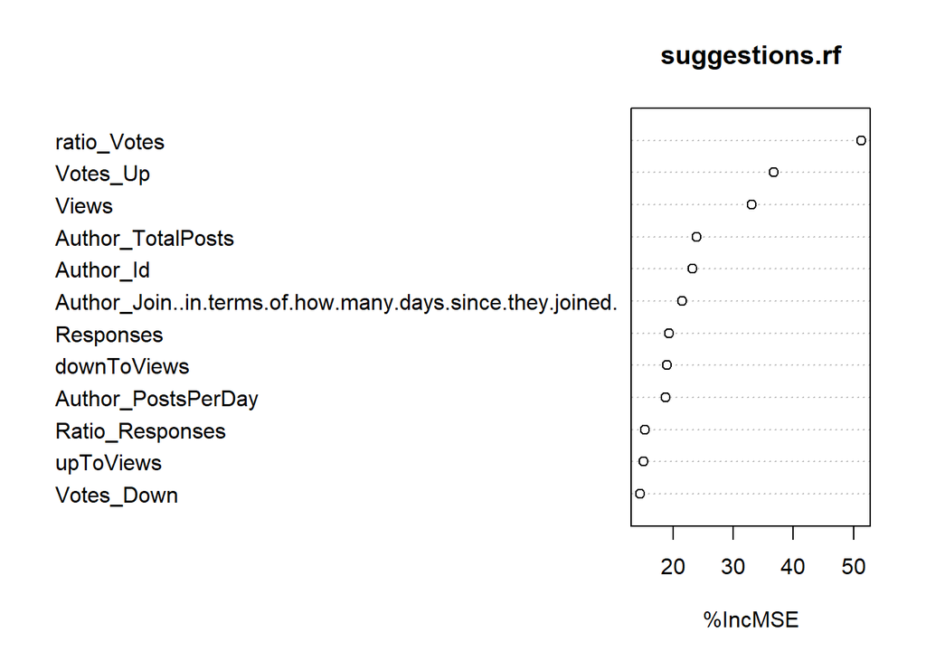

```r
varImpPlot(suggestions.rf,type=1)
```

> Checking the partial dependence plots for Views, votes_down and ratio_Votes. Partial plots gives a graphical depiction of the marginal effect of a variable on class probability.

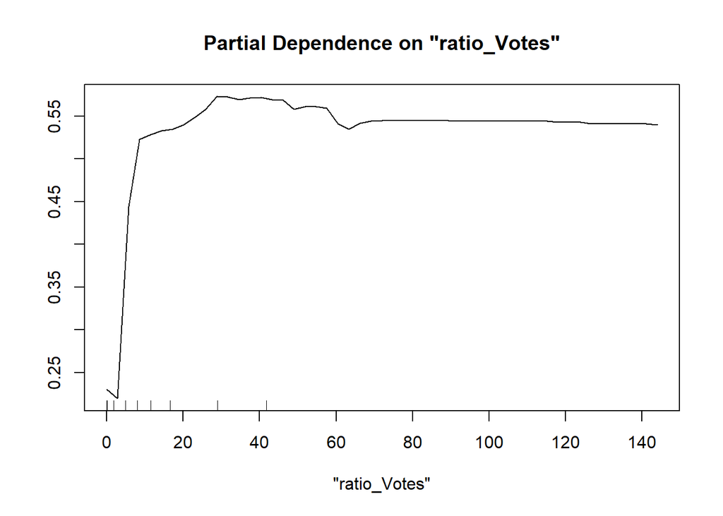

```r
partialPlot(suggestions.rf, suggestions_new1, x.var = "ratio_Votes")
```

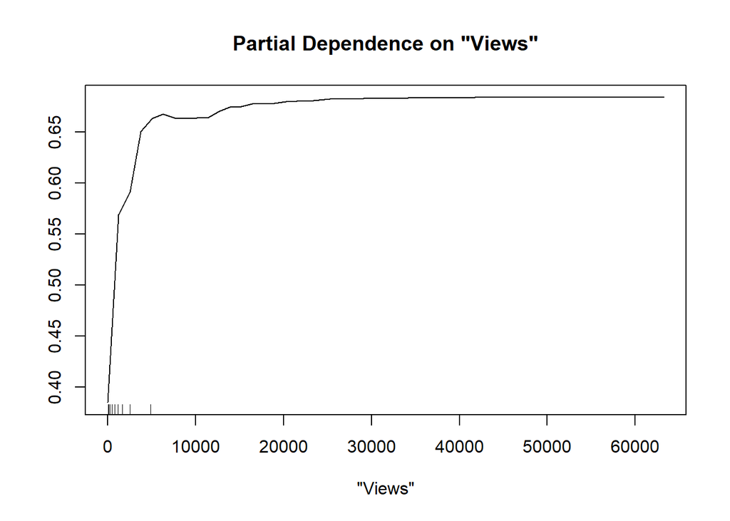

```r
partialPlot(suggestions.rf, suggestions_new1, x.var = "Views")
```

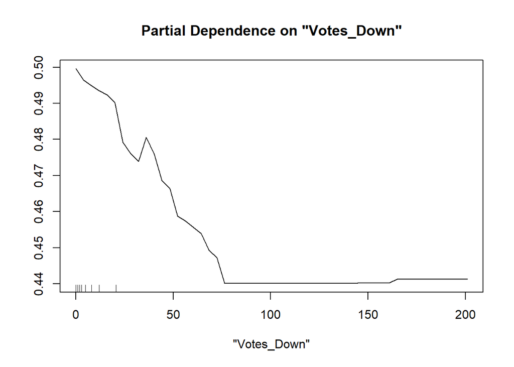

```r
partialPlot(suggestions.rf, suggestions_new1, x.var = "Votes_Down")
```

> Summary of Features selectes

```r
feature_data=read.xlsx("Feature Selection Results.xlsx",sheetIndex = 1)
kable(feature_data)
```

| No | Forward…AIC | Backward…AIC | Both…AIC | Lasso…Best.Lamba | Lasso.1SE |
| --- | --- | --- | --- | --- | --- |
| Responses | Yes | Yes | Yes | Yes | Yes |
| Views | Yes | Yes | Yes | Yes | Yes |
| Votes_Up | No | No | Yes | Yes | No |
| Votes_Down | Yes | Yes | No | Yes | Yes |
| Author_Id | Yes | Yes | Yes | Yes | Yes |
| Author_Join (in terms of how many days since they joined) | No | No | No | Yes | No |
| Author_TotalPosts | No | No | Yes | Yes | No |
| Author_PostsPerDay | Yes | Yes | Yes | Yes | Yes |
| Ratio_Responses | Yes | Yes | Yes | Yes | Yes |
| Ratio_Votes | Yes | Yes | Yes | Yes | Yes |
| upToViews | No | No | No | Yes | Yes |
| downToViews | yes | yes | No | Yes | No |

### Modelling Suggestion Quality - Observations

*From Observations so far from regression analysis, Correlation Analysis, Best Subset Selection, Regularized regression and Tree based methods, following are the parameters that are most predictive of whether a suggestion is good are not.*

-*Ratio_Votes* -*Responses* -*Views* -*Votes_Down* -*Author_PostsPerDay or Author_TotalPosts*

The number of views, number of downvotes and ratio of upvotes to downvotes contribute to predicting a good suggestion. But the Ratio of up and down votes is more significant than the number of Views, from the unregularized regression and Random Forest *

*The ‘age’ of the employee can be considered as the Days since joining for an employee. From the pair plots, we can see that Author_ID and and Author.Join are highly correlated and indicate the “age” of an employee.

From a real-world perspective this the above observations can be interpreted in the following ways. 1. Age of an employee does not matter in their ability to produce good suggestions. 2. The number of votes [Especially downvotes] determine the quality of a suggestion. 3. Authors who are active and have had many posts in the past as well as post frequently [high daily averages], produce good quality suggestions

##### **(j)** Classifier for Predicting good suggestion - Naive Bayes

> Below is just a sample of how a classification task would be like with the above selected features, balanced dataset and Naive Bayes Classifier.

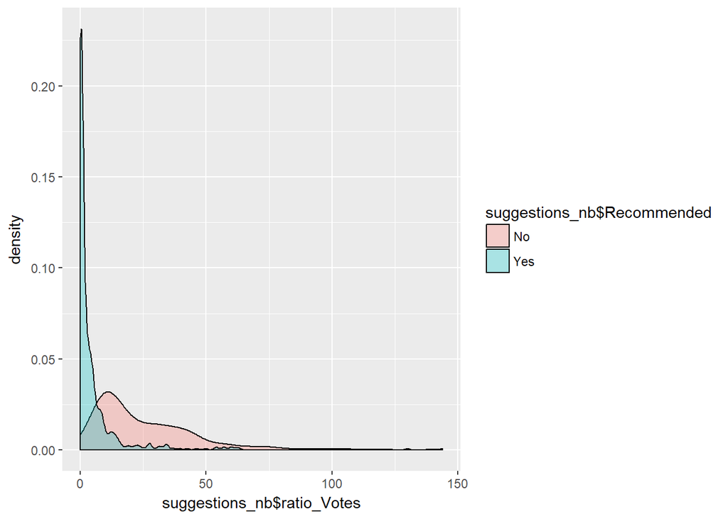

```r
suggestions_nb = subset(suggestions_new2,select = c(Recommended, ratio_Votes, Responses, Views, Votes_Down, Author_TotalPosts, Author_Join..in.terms.of.how.many.days.since.they.joined.))
# shuffling the data
suggestions_nb <- suggestions_nb[sample(nrow(suggestions_nb)),]
suggestions_nb = transform(suggestions_nb,
                   Recommended = mapvalues(Recommended, c(0,1),
                                      c("Yes", "No")))
suggestions_nb["Recommended"] = as.factor(suggestions_nb$Recommended)

#Density Plots to see how Naive bayes may perform
ggplot(suggestions_nb, aes(suggestions_nb$ratio_Votes, fill= suggestions_nb$Recommended)) + geom_density(alpha=0.3)
```

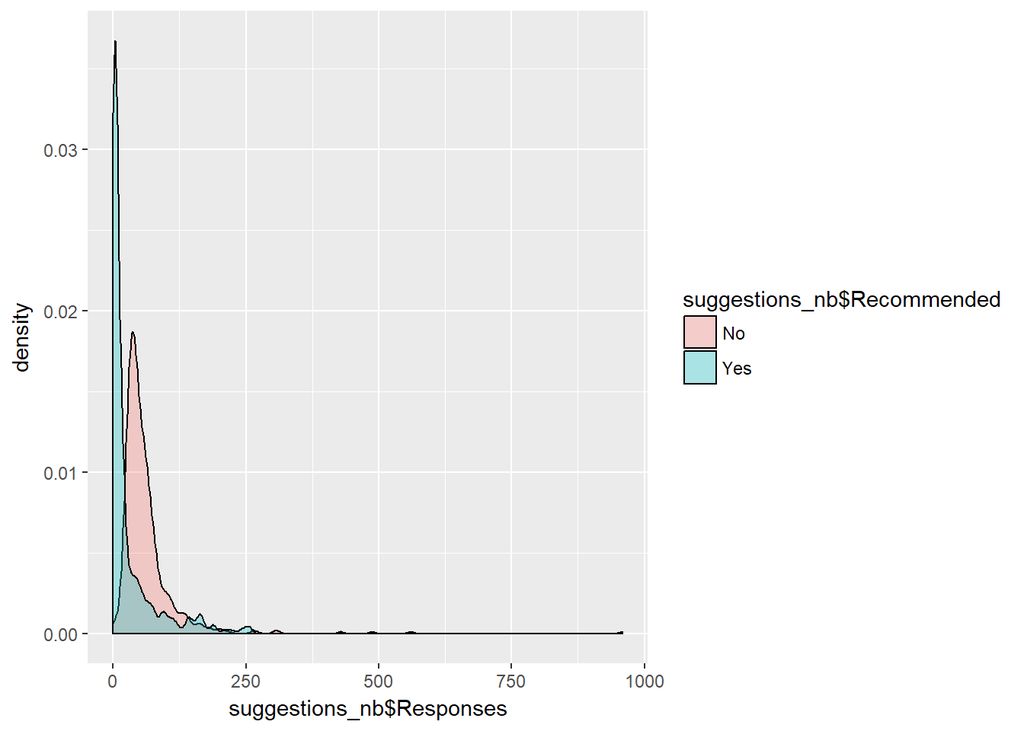

```r
ggplot(suggestions_nb, aes(suggestions_nb$Responses, fill= suggestions_nb$Recommended)) + geom_density(alpha=0.3)
```

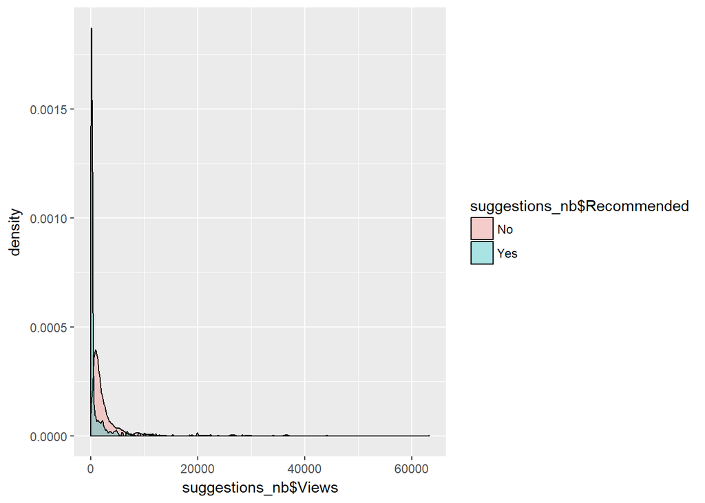

```r
ggplot(suggestions_nb, aes(suggestions_nb$Views, fill= suggestions_nb$Recommended)) + geom_density(alpha=0.3)
```

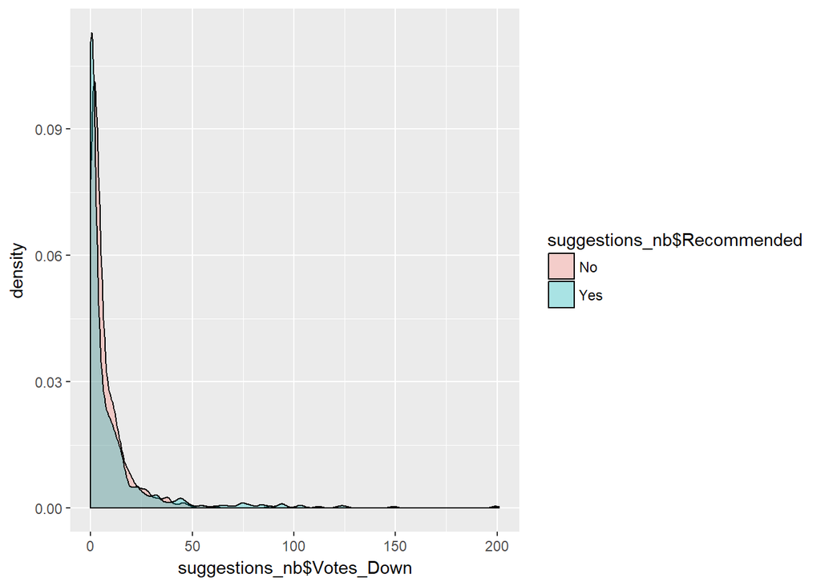

```r
ggplot(suggestions_nb, aes(suggestions_nb$Votes_Down, fill= suggestions_nb$Recommended)) + geom_density(alpha=0.3)
```

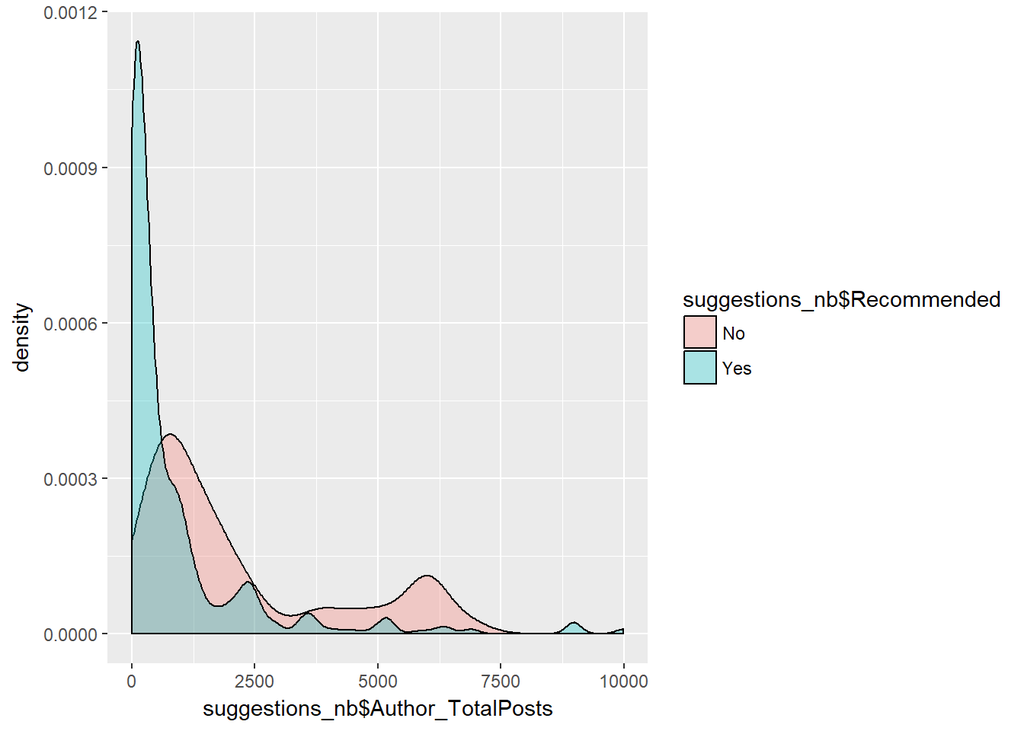

```r
ggplot(suggestions_nb, aes(suggestions_nb$Author_TotalPosts, fill= suggestions_nb$Recommended)) + geom_density(alpha=0.3)
```

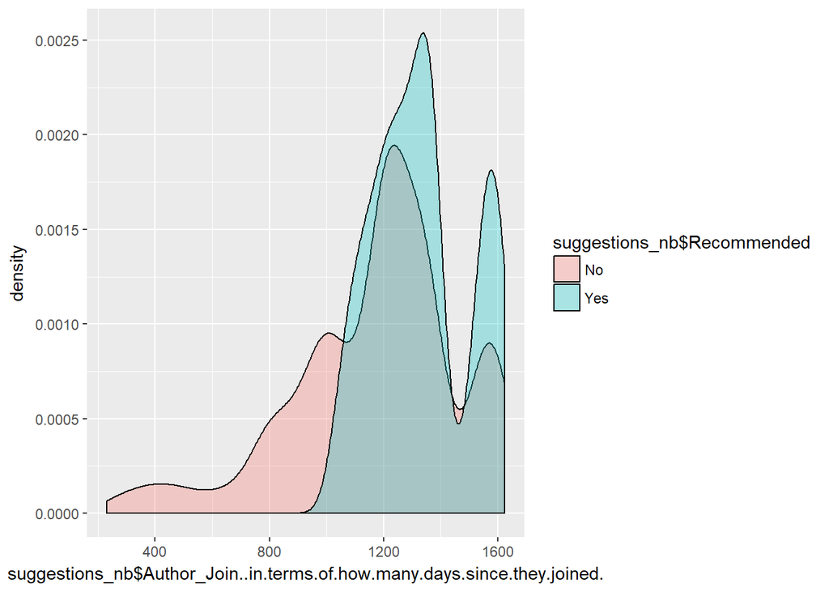

```r
ggplot(suggestions_nb, aes(suggestions_nb$Author_Join..in.terms.of.how.many.days.since.they.joined., fill= suggestions_nb$Recommended)) + geom_density(alpha=0.3)
```

**From the above density plots(if we zoom in) - we can see that Responses, Views and Ratio_Votes seems to be separating the Recommended classes pretty well.**

```r
sugg.nb = NaiveBayes(Recommended~., data = suggestions_nb, usekernel = TRUE)
sugg.nb.pred <- predict(sugg.nb,suggestions_nb)
table(sugg.nb.pred$class,suggestions_nb$Recommended)
```

```
##
##        No Yes
##   No  544  95
##   Yes  18 467
```

```r
print(paste0("Misclassification Rate :", mean(sugg.nb.pred$class != suggestions_nb$Recommended))) ## misclassification rate
```

```
## [1] "Misclassification Rate :0.100533807829181"
```

Naive Bayes Classifier is able to classify well with a misclassification of only 10% but the prevalence is 50% Thus Classifier performance is good.

### Ranking Authors

> To Check If Employees can be ranked on their ability to make good suggestions, we are first aggregating the suggestions data to form a new dataset with aggregated “suggestion data per author”. We are also engineering a factor that can be used as an indicator of the ability of an author to make good suggestions.

The engineered column is a weighted combination of proportion of recommended posts and total posts per author. This is to ensure that authors with small number of total posts do not geta higher ranking owing to just a few good suggestions.At the same time, factor is chosen to give higher rank to an author with higher posts if both of them had same ratio of recommended to not recommended posts

If we are able to create a prediction model for this data on the ranking factor, we should be able to build a completely automated suggestion ranking systems as well as an author ranking system.

##### **(k)** Constructing the Data set

```r
colnames(suggestions_clean)[7]<- "Tenure"

authordf <- suggestions_clean %>%
  dplyr::select(Author_Id, Tenure, Author_TotalPosts, Author_PostsPerDay,
         Votes_Down, Votes_Up,Views,Responses, Recommended) %>%
  dplyr::group_by(Author_Id,Tenure, Author_TotalPosts, Author_PostsPerDay) %>%
  dplyr::summarise(Votes_Down_mean = mean(Votes_Down), Votes_Up_mean = mean(Votes_Up), Views_mean = mean(Views),Responses_mean = mean(Responses),
            Votes_Down_sum = sum(Votes_Down), Votes_Up_sum = sum(Votes_Up), Views_sum = sum(Views),Responses_sum = sum(Responses), Recommended_yes=sum(Recommended[Recommended==1])+1,
Recommended_no = length(Recommended[Recommended==0]), ratio_yes_total = Recommended_yes/(Recommended_no+Recommended_yes))
```

```r
attach(authordf)
authordf["sum_recommended"] = Recommended_no+Recommended_yes
authordf["ratio_recommended"] = authordf$ratio_yes_total*10 +(Recommended_no+Recommended_yes)*0.35
authordf <- subset(authordf, select=-Recommended_yes)
authordf <- subset(authordf, select=-Recommended_no)
authordf <- subset(authordf, select=-sum_recommended)
authordf <- subset(authordf, select=-ratio_yes_total)
detach(authordf)
```

#### **(l)** Feature Selection - Regression, Stepwise and Lasso

After assigning a rank to every author, we are trying various methods to check if the rank is predictable using the existing data.

> Linear Regression

```r
options(scipen = 4)
authordf.lm = lm(ratio_recommended~.,data = authordf)
summary(authordf.lm)
```

```
##
## Call:
## lm(formula = ratio_recommended ~ ., data = authordf)
##
## Residuals:
##     Min      1Q  Median      3Q     Max
## -13.807  -0.805   0.594   0.740  37.017
##
## Coefficients:
##                         Estimate    Std. Error t value Pr(>|t|)
## (Intercept)         5.6884928962  0.5738912402   9.912  < 2e-16 ***
## Author_Id          -0.0000003233  0.0000003075  -1.051    0.293
## Tenure             -0.0003625102  0.0003685647  -0.984    0.325
## Author_TotalPosts  -0.0000673362  0.0000611292  -1.102    0.271
## Author_PostsPerDay -0.0807759293  0.0581802458  -1.388    0.165
## Votes_Down_mean    -0.0476625869  0.0061367465  -7.767 9.83e-15 ***
## Votes_Up_mean       0.0192795675  0.0013942226  13.828  < 2e-16 ***
## Views_mean          0.0002057723  0.0000425512   4.836 1.37e-06 ***
## Responses_mean     -0.0422230890  0.0027078716 -15.593  < 2e-16 ***
## Votes_Down_sum      0.0117361777  0.0012708996   9.235  < 2e-16 ***
## Votes_Up_sum       -0.0063789582  0.0002906242 -21.949  < 2e-16 ***
## Views_sum          -0.0000658450  0.0000099863  -6.594 4.77e-11 ***
## Responses_sum       0.0175063732  0.0004544298  38.524  < 2e-16 ***
## ---
## Signif. codes:  0 '***' 0.001 '**' 0.01 '*' 0.05 '.' 0.1 ' ' 1
##
## Residual standard error: 1.429 on 4679 degrees of freedom
## Multiple R-squared:  0.6201, Adjusted R-squared:  0.6191
## F-statistic: 636.3 on 12 and 4679 DF,  p-value: < 2.2e-16
```

**From the above linear regression model we can infer that the following features seem significant - Votes Down mean, Votes Up mean, views mean, responses mean, votes down sum, votes up sum, views sum and responses sum**

> Pair Plots

Looking at the correlations between variables using Pair Plots

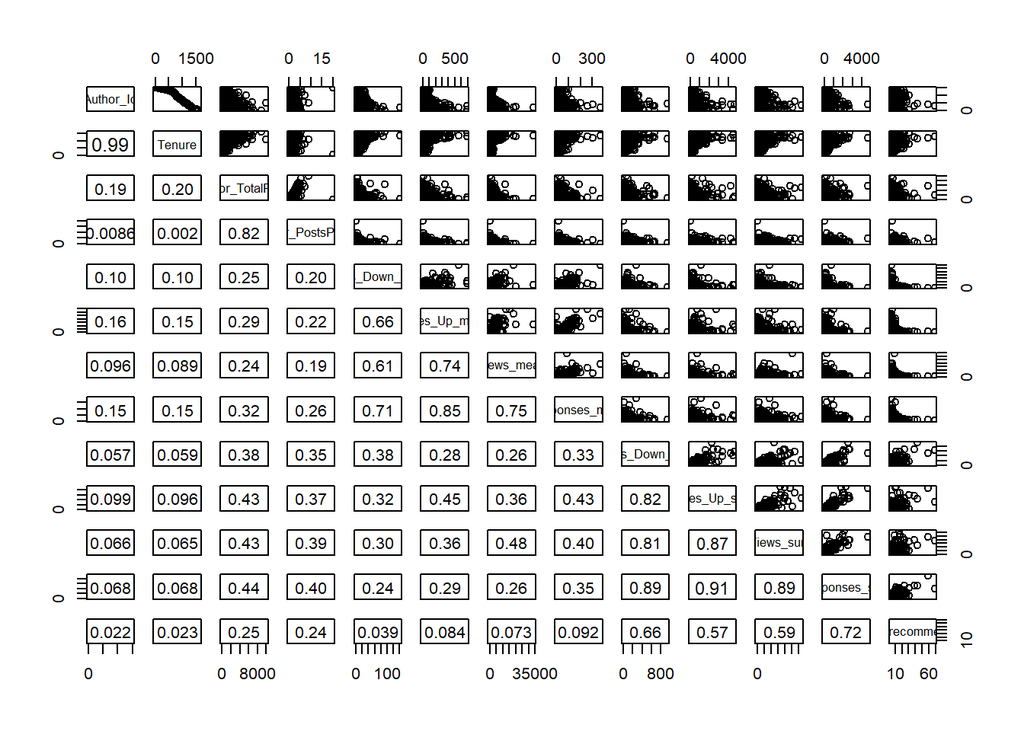

```r
panel.cor <- function(x, y, digits = 2, prefix = "", cex.cor, ...)
{
    usr <- par("usr"); on.exit(par(usr))
    par(usr = c(0, 1, 0, 1))
    r <- abs(cor(x, y))
    txt <- format(c(r, 0.123456789), digits = digits)[1]
    txt <- paste0(prefix, txt)
    if(missing(cex.cor)) cex.cor <- 0.8/strwidth(txt)
    text(0.5, 0.5, txt, cex = pmax(1, cex.cor * r))
}

authordf.var.names = names(authordf)
# Use panel.cor to display correlations in lower panel.
pairs(authordf[,authordf.var.names], lower.panel = panel.cor)
```

From the above results - we can infer that the following are highly corelated(above 0.89):

Votes_Up_Sum and Responses_Sum

Views_Sum and Responses_Sum

Author_ID and Tenure

> Best Subset

```r
authordf <- na.omit(authordf)
regfit.full <- regsubsets(ratio_recommended ~ ., authordf, nvmax = 12)
reg.summary <- summary(regfit.full)
reg.summary
```

```
## Subset selection object
## Call: regsubsets.formula(ratio_recommended ~ ., authordf, nvmax = 12)
## 12 Variables  (and intercept)
##                    Forced in Forced out
## Author_Id              FALSE      FALSE
## Tenure                 FALSE      FALSE
## Author_TotalPosts      FALSE      FALSE
## Author_PostsPerDay     FALSE      FALSE
## Votes_Down_mean        FALSE      FALSE
## Votes_Up_mean          FALSE      FALSE
## Views_mean             FALSE      FALSE
## Responses_mean         FALSE      FALSE
## Votes_Down_sum         FALSE      FALSE
## Votes_Up_sum           FALSE      FALSE
## Views_sum              FALSE      FALSE
## Responses_sum          FALSE      FALSE
## 1 subsets of each size up to 12
## Selection Algorithm: exhaustive
##           Author_Id Tenure Author_TotalPosts Author_PostsPerDay
## 1  ( 1 )  " "       " "    " "               " "
## 2  ( 1 )  " "       " "    " "               " "
## 3  ( 1 )  " "       " "    " "               " "
## 4  ( 1 )  " "       " "    " "               " "
## 5  ( 1 )  " "       " "    " "               " "
## 6  ( 1 )  " "       " "    " "               " "
## 7  ( 1 )  " "       " "    " "               " "
## 8  ( 1 )  " "       " "    " "               " "
## 9  ( 1 )  " "       " "    " "               "*"
## 10  ( 1 ) " "       " "    "*"               "*"
## 11  ( 1 ) "*"       " "    "*"               "*"
## 12  ( 1 ) "*"       "*"    "*"               "*"
##           Votes_Down_mean Votes_Up_mean Views_mean Responses_mean
## 1  ( 1 )  " "             " "           " "        " "
## 2  ( 1 )  " "             " "           " "        " "
## 3  ( 1 )  " "             " "           " "        "*"
## 4  ( 1 )  " "             "*"           " "        "*"
## 5  ( 1 )  " "             "*"           " "        "*"
## 6  ( 1 )  "*"             "*"           " "        "*"
## 7  ( 1 )  "*"             "*"           " "        "*"
## 8  ( 1 )  "*"             "*"           "*"        "*"
## 9  ( 1 )  "*"             "*"           "*"        "*"
## 10  ( 1 ) "*"             "*"           "*"        "*"
## 11  ( 1 ) "*"             "*"           "*"        "*"
## 12  ( 1 ) "*"             "*"           "*"        "*"
##           Votes_Down_sum Votes_Up_sum Views_sum Responses_sum
## 1  ( 1 )  " "            " "          " "       "*"
## 2  ( 1 )  " "            "*"          " "       "*"
## 3  ( 1 )  " "            "*"          " "       "*"
## 4  ( 1 )  " "            "*"          " "       "*"
## 5  ( 1 )  "*"            "*"          " "       "*"
## 6  ( 1 )  "*"            "*"          " "       "*"
## 7  ( 1 )  "*"            "*"          "*"       "*"
## 8  ( 1 )  "*"            "*"          "*"       "*"
## 9  ( 1 )  "*"            "*"          "*"       "*"
## 10  ( 1 ) "*"            "*"          "*"       "*"
## 11  ( 1 ) "*"            "*"          "*"       "*"
## 12  ( 1 ) "*"            "*"          "*"       "*"
```

From the data above, some of the most predictive features include Responses_mean, Votes_Up_sum, Responses_sum,Votes_Up_mean and Votes_down_sum.

> R Square , RSS, AIC and BIC criterion minimizing models

```r
par(mfrow=c(2,2))
plot(reg.summary$rss,xlab="Number of Variables",ylab="RSS",type="l")
plot(reg.summary$adjr2,xlab="Number of Variables",ylab="Adjusted RSq",type="l")
which.max(reg.summary$adjr2)
```

```
## [1] 10
```

```r
points(11,reg.summary$adjr2[11], col="red",cex=2,pch=20)
plot(reg.summary$cp,xlab="Number of Variables",ylab="Cp",type='l')
which.min(reg.summary$cp)
```

```
## [1] 9
```

```r
points(10,reg.summary$cp[10],col="red",cex=2,pch=20)
which.min(reg.summary$bic)
```

```
## [1] 9
```

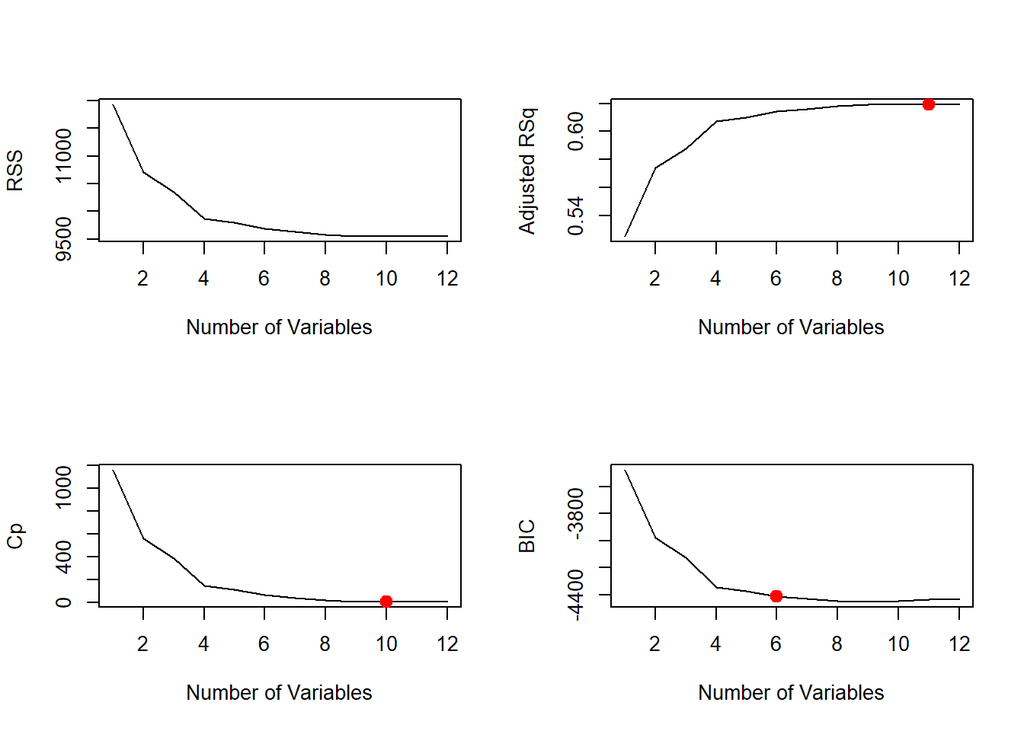

```r
plot(reg.summary$bic,xlab="Number of Variables",ylab="BIC",type='l')
points(6,reg.summary$bic[6],col="red",cex=2,pch=20)
```

> LASSO

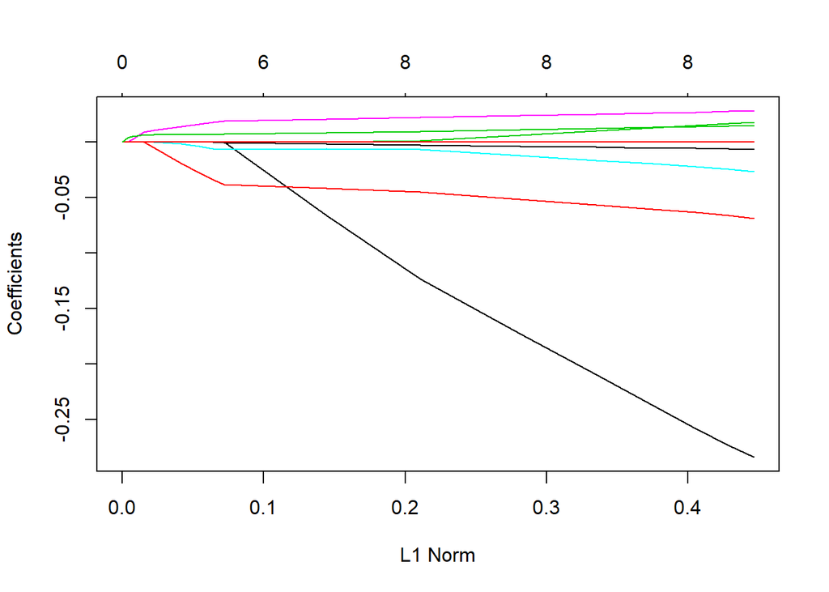

```r
x <- model.matrix(ratio_recommended~.,authordf)[,-1]
y <- authordf$ratio_recommended

# Split data into test and train
set.seed(1)
train <- sample(1:nrow(x), nrow(x)/2)
test <- (-train)
y.test <- y[test]

# Predefined grid of lambda values:
grid=10^seq(10,-2, length =100)

lasso.mod=glmnet(x[train,],y[train],alpha=1,lambda=grid)
plot(lasso.mod)
```

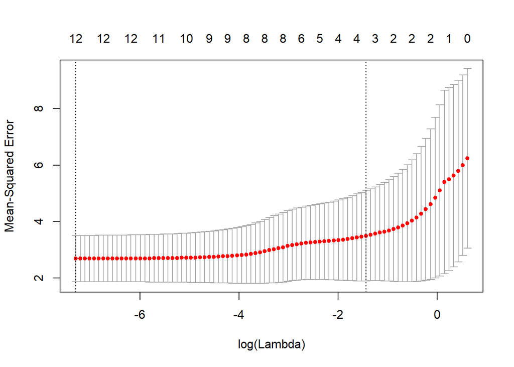

```r
set.seed(1)
cv.out=cv.glmnet(x[train,],y[train],alpha=1)
plot(cv.out)
```

```r
lammin = cv.out$lambda.min
lasso.pred=predict(lasso.mod,s=lammin,newx=x[test,])
mean((lasso.pred-y.test)^2)
```

```
## [1] 2.057002
```

```r
lasso.coef=predict(cv.out,type="coefficients",s=lammin)[1:12,]

lasso.coef
```

```
##        (Intercept)          Author_Id             Tenure
##     5.661760421265    -0.000000292283    -0.000393804160
##  Author_TotalPosts Author_PostsPerDay    Votes_Down_mean
##     0.000236860186    -0.553274049995    -0.076617849787
##      Votes_Up_mean         Views_mean     Responses_mean
##     0.020441520938     0.000152378898    -0.033088135326
##     Votes_Down_sum       Votes_Up_sum          Views_sum
##     0.029900327188    -0.007150790142    -0.000080547405
```

The min lambda picks up all features.

```r
lam1se = cv.out$lambda.1se
lasso.pred=predict(lasso.mod,s=lam1se,newx=x[test,])
mean((lasso.pred-y.test)^2)
```

```
## [1] 2.141246
```

```r
lasso.coef=predict(cv.out,type="coefficients",s=lam1se)[1:12,]

lasso.coef
```

```
##        (Intercept)          Author_Id             Tenure
##       4.9299911657       0.0000000000       0.0000000000
##  Author_TotalPosts Author_PostsPerDay    Votes_Down_mean
##       0.0000000000       0.0000000000      -0.0161317566
##      Votes_Up_mean         Views_mean     Responses_mean
##       0.0000000000       0.0000000000      -0.0007367159
##     Votes_Down_sum       Votes_Up_sum          Views_sum
##       0.0130723929       0.0000000000       0.0000000000
```

The 1SE lambda picks up 4 variables - Votes_Down_sum, Votes_Down_mean,Responses_sum and Responses_mean.

> Summary of Features Selected

```r
feature_data_Q3=read.xlsx("FeatureSelection-Q3.xlsx",sheetIndex = 1)
kable(feature_data_Q3)
```

[output not shown]

#### **(m)** Checking the MSE of a predictive model

> Linear Prediction with all features**

Taking all the features from the dataset, we are building a linear predictive model. It is notable that the MSE reduces after feature selection from previous steps.

```r
authordf.lm = lm(ratio_recommended~.,data = authordf,subset=train)
mse1 <- with(authordf, mean((ratio_recommended - predict(authordf.lm, authordf))[-train]^2))
```

```r
print(paste0("Mean Square Error: ",mse1))
```

```
## [1] "Mean Square Error: 2.14613470675613"
```

```r
predictions <- predict(authordf.lm, data = authordf, subset=test)
actuals_preds <- data.frame(cbind(actuals=authordf$ratio_recommended, predicteds=predictions))
min_max_accuracy <- mean(apply(actuals_preds, 1, min) / apply(actuals_preds, 1, max))
print(paste0("accuracy : ", min_max_accuracy))
```

```
## [1] "accuracy : 0.819552617872049"
```

## **Linear Prediction with selected features**

```r
authordf_filtered = subset(authordf,select = c(ratio_recommended, Votes_Up_mean , Responses_mean,Responses_sum,Votes_Up_sum))

authordf.lm1 = lm(ratio_recommended~.,data = authordf_filtered,subset=train)
mse1 <- with(authordf_filtered, mean((ratio_recommended - predict(authordf.lm1, authordf_filtered))[-train]^2))
print(paste0("Mean Square Error : ",mse1))
```

```
## [1] "Mean Square Error : 1.73413456603269"
```

**Ranking employees based on their ability to make good predictions**

We have aggregated the data based on Author_Id - through which we got the following columns like Responses_mean, Views_Sum, Votes_Up_mean etc. To determine whether the data will be appropriate to rank the employees on their ability to offer quality suggestions, we formulates a new column ‘ratio_recommended’. This column is factor of the proportion of good recommendations based on which we will be able to rank authors on their suggestions. Yes, we can extend the same data to rank the employees. Our feature selection process has results in the following features being most significant:

Votes_Up_Mean

Responses_Mean

Responses_Sum

Votes_Up_Sum

The above features are not author specific i.e., they will get aggregated when certain employees are taken as a group. This means that certain employees can be aggregated to perform equal to good authors. Our process doesn’t select features which are based on an individual like Tenure. Hence, we conclude that by taking employees in groups which have their ‘ratio_recommended’ higher than a certain threshold will improve the quality of recommendations in the company.

Recommendations to your IT department:

Attributes:

The can capture the sequence of the suggestions, whether some are followups to a certain or are new ones.

The category under which these suggestions fall.

The time the suggestion was made and hence we can calculate if a suggestion has higher views as it been there for a long time or was it recently posted.

Capture the authors who are voting and apply a weightage to vote depending on the rank of the author.